# What Election Returns Can and Cannot Show

Complete, official, and permanently silent about who did it

Democracy’s Data

Last updated September 13, 2026 at 10:53a EDT

An election produces one number that matters more than any other number in this book: who won. An election return is the official record of that outcome. It is the statement, made by the officials who ran the election, of how many votes each candidate received in each place.

Nobody produces this record for the country as a whole. Elections in the United States are run by states, and in practice by 6,461 counties, cities and townships, each of which certifies its own result under its own law. To certify a result is to declare it final and lawful, on a named officer’s authority. The return exists because that declaration has to exist: somebody must be seated, a recount must have a number to start from, and a court must have a record to examine. Research was never part of the plan.

Three properties follow, and every brief in this cluster leans on at least one of them. A return is **complete**: every ballot the count accepted is in the total, nothing was sampled, and no margin of error (no statement of how far off it could be) sits beneath it. It is **official**: an officer attested it under law, which is more than any survey or any compilation can say. And it is permanently **silent about who did it**. The ballot is secret by design, so the authoritative record of the outcome contains no record of any voter.

## Where the data comes from, and what it is for

A return is not collected; it accumulates. It is written by the offices that run the election, in the act of finishing it, and its shape follows the machinery that produced it.

**Who is in it, and how they got there.** Candidates, by name, with vote totals beside them. Voters are in it only as counts. Every ballot lawfully cast and accepted is added into the total of a precinct (the small area served by one polling place), and from there the totals are summed upward. Nobody is in a return as a person, and no amount of detail changes that: even the finest published return is a total.

**Who it was made for.** The law’s own deadlines. State statutes require each county to canvass its returns, which means to check, total and confirm them, and require the state’s chief election officer to certify the statewide result.[^1] The certified return seats the winner, starts the recount clock, and serves as the evidence in any court fight over the outcome. Election-night numbers are a courtesy to the public. Certification is the obligation, and the certified figures are the data.

**What it costs to get.** Any one state’s certified result is free, published by the Secretary of State or an equivalent office. The whole country is the expensive part. No federal agency assembles the fifty-one sets of returns (fifty states and the District of Columbia) into one file, so every national dataset you have ever seen is a private act of assembly. The county-returns brief measures what that assembly costs, jurisdiction by jurisdiction.

**What has already been done to it.** More than to any other “raw” number in this book. By the time you read a certified county total, precinct tallies have been canvassed, corrected, summed, sworn to, and possibly amended after a recount. A national compilation adds one more layer: a compiler’s reconciliation of thousands of local documents, made under no obligation at all. That last layer is the one this chapter measures below.

## Fifty-one publishers, and no national return

The United States has no national vote counter. What exists nationally is **compilation**, and it helps to see who publishes returns at all, at what grain — how fine the units are, precinct or county or state — and under what obligation.

| Publisher | Publishes | Finest grain | Obliged to | If it is wrong |
| --- | --- | --- | --- | --- |
| A county election office | Its own precinct and absentee returns, in its own format | Precinct | Certify a lawful count for its own jurisdiction | Recount and amendment under state law |
| A state’s chief election officer | The certified statewide result, and usually precinct returns | Precinct | Certify the statewide result | Recount and amendment under state law |
| The Clerk of the U.S. House | Official House results, biennially, as a PDF | District | Record the results of House elections | Errata in a later edition |
| The Federal Election Commission | Federal Elections, a biennial workbook of federal races | District or county | Report on federal elections | Errata in a later edition |
| A university or newsroom compilation | A national file assembled from the above | Precinct or county | Nothing – it is a voluntary act | Whatever the compiler decides |

The last row is the one to watch. A national file assembled by a university or a newsroom is enormously useful, and several chapters in this book depend on one. It is also under **no obligation whatever**. It exists because somebody chose to build it, it is corrected if and when the compiler decides, and it can stop.

What does that cost in practice? Add up every county in the country and compare the sum to the certified national total.

| Comparison | One source | Its total | Other source | Their total | Difference |
| --- | --- | --- | --- | --- | --- |
| Georgia Democratic votes | 2,701 precincts summed | 2,548,006 | 159 counties, same source | 2,548,006 | +0 |
| Georgia Democratic votes | 159 counties, state source | 2,548,006 | 159 counties, national compilation | 2,548,017 | -11 |
| Georgia Republican votes | 159 counties, state source | 2,663,110 | 159 counties, national compilation | 2,663,117 | -7 |
| National Democratic votes | 3160 counties summed | 75,006,739 | certified national total | 75,017,613 | -10874 |
| National Republican votes | 3160 counties summed | 77,294,799 | certified national total | 77,302,580 | -7781 |

**The county sums fall 10,874 Democratic votes short of the certified national figure** — itself the sum of the fifty-one state certifications — and a comparable distance short on the Republican side. That is a small fraction of 75,017,613, about a hundredth of one per cent, and it is not evidence of anything sinister. Jurisdictions report at different grains, some states do not report by county at all, and overseas and federal ballots are handled differently from place to place.

But it means there is no single number to check against. The certified national total is itself a sum of certifications, and the “national returns” in any file you download are one compiler’s reconciliation of thousands of local documents.

Look at the Georgia rows too. Summing the state’s 2,701 precincts gives exactly the same total as the state’s own county file — internally consistent, to the vote. Compare the *same state’s* returns as published by the state against the same returns inside a national compilation and they differ by 11 votes. Eleven votes is nothing, and it is also proof that the two files are not the same object.

## Every rung of the ladder is a sum

Returns are published at several grains, and the grains stack into a ladder.

| Rung | Level | Units nationally | A row is |
| --- | --- | --- | --- |
| 0 | ballot | 158,211,780 | one voter’s ballot |
| 1 | precinct | 177,708 | one polling place’s returns |
| 2 | election jurisdiction | 6,461 | one office that runs elections |
| 3 | county | 3,144 | one county’s returns |
| 4 | congressional district | 434 | one seat in the U.S. House |
| 5 | state | 51 | one state’s returns |
| 6 | nation | 1 | the whole electorate |

158,211,780 ballots become 177,708 precinct returns become 3,144 county returns become fifty-one state returns become one national number. Each step upward is a sum, and **a sum cannot be undone**. Knowing that a county split 55–45 tells you nothing about which of its precincts did what, and knowing a precinct’s totals tells you nothing about any ballot in it.

Almost every published claim about American elections lives on rung 3 or above, and almost every interesting question about voters lives on rung 0. That distance is the subject of the levels-of-aggregation chapter, this cluster’s other chapter, which walks the ladder rung by rung. This chapter needs only the ladder’s direction: upward, one way. The ladder is a property of the instrument, not a choice the analyst made.

## The ballot is secret, and that is the whole limit

No election return anywhere links a vote to a voter. This is not a gap in the record-keeping that better record-keeping would close; it is the point of the secret ballot, and every return is a total by construction.

So any claim about *which kinds of people* voted which way is a guess across a gap the data cannot cross. Did suburban women swing? Did mail voters break for one side? Usually that guess is made by ecological inference (inferring what individuals did from group totals), by looking at how places that differ in composition also differ in result. The reasoning runs like this: if precincts where more of the votes arrived by mail also gave the Democrat a larger share, draw the straight line that best fits the precincts and read it off at the point where a precinct would be entirely mail voters. No such precinct exists, but the line has an answer there, and that answer is taken as the Democratic share among mail voters.

Almost nothing in political data lets you check that inference, because the truth is unavailable in principle. Here, for once, it is available. Georgia’s 2020 precinct returns report each candidate’s votes separately by how the ballot arrived — by mail, early in person, or on election day — so the share of mail voters who chose the Democrat is not estimated; it is counted. That means the standard method can be run on the ordinary totals alone and then graded against the counted answer.

| Computed from | Estimate for mail voters | The truth | Error in points | Impossible value |
| --- | --- | --- | --- | --- |
| 2,653 precincts | 194.0% | 64.5% | +129.5 | yes |
| 159 counties | 233.4% | 64.5% | +168.9 | yes |

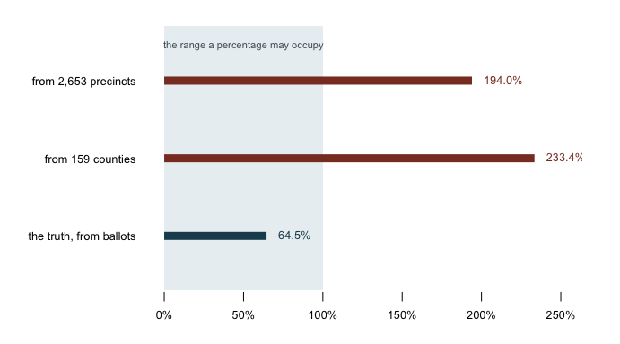

**Figure 1. The share of mail voters who chose the Democrat: two estimates from aggregate returns, and the counted answer from Georgia’s returns by vote method.** Bars fit this comparison because the claim is about a boundary. Each bar’s length is one estimate, the shaded region is the range a percentage is allowed to occupy, and a bar that crosses the dashed 100% line has visibly left the possible. Two of these three do.

**194.0% from the precincts. 233.4% from the counties. The truth is 64.5%.**

The estimates are not close, and more importantly they are not *possible*. A percentage above one hundred is not a wrong answer of the ordinary kind; it is a signal that the method has been asked a question the data cannot answer. And the method returns it without complaint, formatted like a result.

## What this data cannot tell you

**It cannot tell you who any voter chose, at any level of detail.** The ecological grading above uses one state, one election, and one contrast — mail against in-person voting in Georgia in 2020. Ecological inference is not always this bad, and there are methods more careful than the one graded here that would not return an impossible number. What the exhibit establishes is narrower and, for a reader, more useful: the failure mode is real, it is large, it does not announce itself, and the ordinary approach walks straight into it.

**It cannot tell you anything about fraud, and nothing here suggests any.** Certified returns are the most audited numbers in this book — recounts, canvasses, and litigation all attach to them.[^2] The discrepancies shown are between *compilations*, not between counts, and they are the size you would expect from thousands of offices reporting at different grains.

**It cannot tell you which of an election’s several numbers you are holding.** Election-night returns, canvassed returns, certified returns, and amended returns are different objects with the same name, and choosing among them is its own decision — the subject of the election-night and Georgia precinct returns briefs.

**And it cannot promise that its units hold still.** Precincts are renamed, split, merged and renumbered between elections, so a precinct-level comparison across two elections may be comparing units that are not the same ground. That is the precinct-geography brief’s subject, and it is a reason the finest available grain is not always the most useful one.

## Where this data appears in this book

Election returns are the largest cluster in this book. Two chapters lead it — this one, and levels-of-aggregation, which walks the ladder from a single ballot to the national total. Seventeen briefs then put the returns to work:

- `county-returns` — what it costs to assemble the national file no agency publishes, from fifty-one separate publishers.
- `panhandle-claim` — a public claim about race and a primary, tested four ways against Florida’s returns.
- `electoral-map` — where electoral votes are, and where they are actually contested.
- `mapping` — one election on a county map, and the difference between coloring land and counting people.
- `wind-map` — vote swing between two elections, drawn as arrows, and what an arrow has to promise.
- `sparklines` — every state’s presidential vote since 1976, drawn small enough to read down a column.
- `historical-campaigns` — a century and a half of presidential returns in one file.
- `distributions` — four hundred House margins drawn four ways, and the average that hides them.
- `crossover` — one election against the next, one office against another.
- `nationalization` — whether fifty separate elections have become one.
- `bellwether` — counties with perfect records, and why a perfect record predicts nothing.
- `vote-targeting` — the arithmetic campaigns run on precinct returns.
- `ga-precinct-returns` — Georgia’s precinct file, and what happens when a state counts the same ballots twice.
- `precinct-geography` — what it takes to compare precincts across two elections.
- `cast-vote-records` — rung zero: a congressional election recounted from the ballots themselves.
- `residual-votes` — ballots that record no vote, and the ballot designs that produce them.
- `eavs` — the survey the country’s election offices fill in about themselves.

## Sources

- Georgia Secretary of State. Certified precinct-level returns and cast vote records, 2020 general election, via this book’s levels-of-aggregation and Georgia precinct returns chapters. https://results.sos.ga.gov/
- National county-level compilation, via this book’s data-sources chapter. https://github.com/tonmcg/US_County_Level_Election_Results_08-24
- Clerk of the U.S. House of Representatives. *Statistics of the Congressional Election*, biennial. https://history.house.gov/Institution/Election-Statistics/Election-Statistics/, every volume from 1920 on. The Clerk’s own address for the series, https://clerk.house.gov/Votes/ElectionStatistics, no longer resolved when this was last checked.
- Federal Election Commission. *Federal Elections*, biennial. https://www.fec.gov/introduction-campaign-finance/election-results-and-voting-information/
- King, Gary (1997). *A Solution to the Ecological Inference Problem: Reconstructing Individual Behavior from Aggregate Data.* Princeton University Press. https://press.princeton.edu/books/paperback/9780691012407/a-solution-to-the-ecological-inference-problem
- Robinson, W. S. (1950). “Ecological Correlations and the Behavior of Individuals.” *American Sociological Review* 15(3): 351–357. https://www.jstor.org/stable/2087176
- Fla. Stat. §102.111, the county-to-state canvass Florida’s law prescribes, and 3 U.S.C. §5, the federal deadline for certifying presidential electors. https://www.law.cornell.edu/uscode/text/3/5

**The data itself**

Every figure above is drawn from these tables. They are plain CSV, they open in a spreadsheet, and they are yours to take further.

`ecological.csv`, `ladder.csv`, `national.csv`, `sources.csv`

**Your turn**

None of these is answered above, and every one can be answered from the tables you just opened.

- `ladder.csv` gives each rung’s `units_nationally` and, in `published_for`, who actually publishes it. Find the rung where publication stops covering the whole country. What is the finest level you can actually get everywhere?
- `ecological.csv` holds an estimate that came out impossible, in `estimate_mail`, with the truth beside it in `truth_mail`. Work out how far off each estimate was. Then say what made the estimates impossible rather than merely wrong.
- `sources.csv` lists each publisher’s `finest_grain` and what it is `obliged_to` do. Find the publisher with the finest grain and the one with the widest reach. Are they ever the same body?
- `national.csv` compares two sums of the same votes in `its_total` and `their_total`. The first Georgia row agrees exactly. Work out what would have had to happen for it to disagree.
[^1]: Florida’s arrangement is typical: each county canvassing board reports to a state Elections Canvassing Commission, which certifies, Fla. Stat. §102.111, http://www.leg.state.fl.us/statutes/index.cfm?App_mode=Display_Statute&URL=0100-0199/0102/Sections/0102.111.html. For presidential electors, federal law now sets the deadline: each state’s governor must certify its result at least six days before the electors meet, 3 U.S.C. §5, https://www.law.cornell.edu/uscode/text/3/5.
[^2]: For presidential elections the federal rules for certifying, transmitting and objecting to a state’s result are 3 U.S.C. §§5–15, as rewritten by the Electoral Count Reform Act of 2022: https://www.law.cornell.edu/uscode/text/3/15.